```python
import scipy
import numpy as np
import PIL
from PIL import Image

import matplotlib
import matplotlib.pyplot as plt
import glob
import os
from skimage import io, color
import cv2
import sklearn
from skimage import data
from skimage import filters
from skimage import exposure
from sklearn.model_selection import train_test_split
from sklearn.pipeline import Pipeline
from sklearn.naive_bayes import MultinomialNB
from sklearn.neighbors import KNeighborsClassifier
from sklearn.model_selection import cross_val_score
from sklearn.metrics import f1_score
from sklearn.metrics import confusion_matrix

import pickle
import imageio
import glob
```

# First change the name of the data

```python
#change the name of the images and change the resolution to 256 * 256
#but don't strech the images, remain the original height to width ratio
#if the image is smaller than 256 * 256, enlarge the image so that the smallest edge is 256 pxs
#if the image is larger than 256 * 256 in both edge, resize the image so that the smallest edge is 256 px
#and then, cut the image so that we want the middle 256 * 256 pixels

def resize_and_cut(name, result_name):
    im = Image.open(name)
    mywidth = 192
    myheight = 192
    imagewidth = (im.size[0])
    imageheight = (im.size[1])
    if (imagewidth < imageheight):
        wpercent = (mywidth/float(imagewidth))
        hsize = int((float(imageheight)*float(wpercent)))
        im = im.resize((mywidth,hsize), PIL.Image.ANTIALIAS)
        difference = (hsize - myheight) / 2
        area = (0, difference, mywidth, hsize - difference)
        cropped_img = im.crop(area)
        cropped_img.save(result_name)
    else:
        hpercent = (myheight/float(imageheight))
        wsize = int((float(imagewidth)*float(hpercent)))
        im = im.resize((wsize,myheight), PIL.Image.ANTIALIAS)
        difference = (wsize - mywidth) /2
        area = (difference, 0, wsize - difference, myheight)
        cropped_img = im.crop(area)
        cropped_img.save(result_name)
    os.remove(name)

def change_all_size():
    for folder_name in glob.glob('images/*'):
        count = 1
        name_list = []
        for name in glob.glob('%s/*' %folder_name):
            if (name.endswith(".jpg")):
                name_list.append([name, '%s/%s.jpg' %(folder_name,count)])
                count +=1
        for name in name_list:
            resize_and_cut(name[0], name[1])
```

```python
#change_all_size()
```

# This is the initial thoughts: something that is within the spirit of A3.

## But it turns out that this way doesn't perform well. After some researchs, I think there shall be other algorithms first to separate the desired image from the complex backgrounds.

```python
# Put images of the same bird categories into a numpy array
# Put all images into a dictionary
def put_in_numpy_array():
    dummy_value = 0
    images = []
    for folder_name in glob.glob('images/*'):
        for name in glob.glob('%s/*' %folder_name):
            img = io.imread(name)
            images.append(img)

    return images

def put_in_numpy_array2():
    dummy_value = 0
    images = []
    for folder_name in glob.glob('images2/*'):
        for name in glob.glob('%s/*' %folder_name):
            img = io.imread(name)
            images.append(img)

    return images
```

```python
# Get the Y value of all images, concatenated
def get_all_Y():
    dummy_value = 0
    for folder_name in glob.glob('images/*'):
        value = (folder_name[7:10])
        length = (len(glob.glob('%s/*' %folder_name)))
        if dummy_value == 0:
            all_Y = np.full((1, int('%s' %length)), value)[0]
            dummy_value = 1
        else:
            new_input = np.full((1, int('%s' %length)), value)[0]
            all_Y = np.concatenate((all_Y, new_input), axis=0)
    return all_Y

def get_all_Y2():
    dummy_value = 0
    for folder_name in glob.glob('images2/*'):
        value = (folder_name[8:11])
        length = (len(glob.glob('%s/*' %folder_name)))
        if dummy_value == 0:
            all_Y = np.full((1, int('%s' %length)), value)[0]
            dummy_value = 1
        else:
            new_input = np.full((1, int('%s' %length)), value)[0]
            all_Y = np.concatenate((all_Y, new_input), axis=0)
    return all_Y
```

```python
def sanity_check(all_X, all_Y):
    print(all_X.shape)
    print(all_Y.shape)
    All_Flat_X = np.array([image.flatten() for image in all_X])
    print(All_Flat_X.shape)
    return All_Flat_X
```

```python
def split_train_and_test(All_Flat_X, all_Y):
    # This only splits a numpy array into two random sub-arrays,
    # but if you're clever you can also use it to get a validation set with just one more line of code

    # Your code goes here
    Train_X, Test_X, Train_y, Test_y = sklearn.model_selection.train_test_split(All_Flat_X, all_Y, test_size=0.20, random_state=42)

    # Print out the following
    print (len(Train_X), len(Train_y), len(Test_X), len(Test_y))
    print (Train_X[0])

    return (Train_X, Test_X, Train_y, Test_y)
```

```python
def fit_model(Train_X, Train_y, Test_X, Test_y):
    model = Pipeline([
        ('MultinomialNB',MultinomialNB())
    ])

    model.fit(Train_X,Train_y)
    predict_accuracy = sum(cross_val_score(model, Test_X, Test_y, cv=3))/3
    predict = model.predict(Test_X)
    predict_f1_socre = f1_score(Test_y, predict, average='weighted')

    predict_matrix = confusion_matrix(Test_y, predict)
    print(predict_accuracy)
    print(predict_f1_socre)
    print(predict_matrix)
    return model
```

```python
def store_model(model, name):
    f = open(name + '.pckl', 'wb')
    pickle.dump(model, f)
    f.close()
```

```python
def open_model(name):
    f = open(name + '.pckl', 'rb')
    test = pickle.load(f)
    f.close()
    return test
```

# So initially the model ends here. But the accuracy is really low.

## So I decide to check some other ways to increase the accuracy. After some research, I think I shall first make the image segmentation. There are multiple algorithms, but I need to find some of the ones that are useful in this situation.

### This is more like a trying and trying until the segmentation is mostly pleasing

```python
def sample(name):
    windowName = "Edges"
    pictureRaw = cv2.imread(name)

    fig=plt.figure(figsize=(12, 12))
    plt.subplot(2,4,1)
    plt.imshow(pictureRaw[:,:,::-1])
    plt.title('original image')

    ## set to gray
    pictureGray = cv2.cvtColor(pictureRaw,  cv2.COLOR_BGR2GRAY)
    ## blur
    pictureGaussian = cv2.GaussianBlur(pictureGray, (21,21), 0)
    ## canny edge detector - you must specify threshold values
    pictureCanny = cv2.Canny(pictureGaussian, 50, 100)
    ## perform a series of erosions + dilations to remove any small regions of noise
    pictureDilate = cv2.dilate(pictureCanny, None, iterations= 50)
    pictureErode = cv2.erode(pictureDilate, None, iterations=5)

    #the erosion + dilation
    plt.subplot(2,4,2)
    plt.imshow(pictureErode)
    plt.title('erosions + dilations')



    #Otsu thresholding
    Otsu = pictureRaw
    Otsugray = cv2.cvtColor(Otsu,cv2.COLOR_BGR2GRAY)
    Otsuret, Otsuthresh = cv2.threshold(Otsugray,0,255,cv2.THRESH_BINARY_INV+cv2.THRESH_OTSU)
    plt.subplot(2,4,3)
    plt.imshow(Otsuthresh)
    plt.title('Otsu thresholding')


    #combined
    combined = Otsuthresh + pictureErode
    plt.subplot(2,4,4)
    plt.imshow(combined)
    plt.title('combined')

    #masked result
    imask = combined > 0
    canvas = np.full_like(pictureRaw, np.array([0,0,0]), dtype=np.uint8)
    canvas[imask] = pictureRaw[imask]
    plt.subplot(2,4,5)
    plt.imshow(canvas[:,:,::-1])
    plt.title('result of combined mask')


    #grab cut
    grabimg = pictureRaw
    grabmask = np.zeros(grabimg.shape[:2],np.uint8)
    grabbgdModel = np.zeros((1,65),np.float64)
    grabfgdModel = np.zeros((1,65),np.float64)
    grabrect = (50,50,1000,1000)
    cv2.grabCut(grabimg,grabmask,grabrect,grabbgdModel,grabfgdModel,5,cv2.GC_INIT_WITH_RECT)
    grabmask2 = np.where((grabmask==2)|(grabmask==0),0,1).astype('uint8')
    grabimg = grabimg*grabmask2[:,:,np.newaxis]
    fig.add_subplot(2, 4, 6)
    plt.imshow(grabimg[:,:,::-1])
    plt.title('grab Cut')


    '''
    #adaptiveThreshold
    adaptiveimg = cv2.imread(name,0)
    adaptiveimg = cv2.medianBlur(adaptiveimg,5)
    adaptiveret,adaptiveth1 = cv2.threshold(adaptiveimg,127,255,cv2.THRESH_BINARY)
    adaptiveth2 = cv2.adaptiveThreshold(adaptiveimg,255,cv2.ADAPTIVE_THRESH_MEAN_C,\
                cv2.THRESH_BINARY,11,2)
    adaptiveth3 = cv2.adaptiveThreshold(adaptiveimg,255,cv2.ADAPTIVE_THRESH_GAUSSIAN_C,\
                cv2.THRESH_BINARY,11,2)

    fig.add_subplot(2, 4, 6)
    plt.imshow(adaptiveth3[:,:,::-1])
    plt.title('adaptiveThreshold')
    '''

    #combined the Otsu and grab Cut
    imask2 = Otsuthresh > 0
    canvas2 = np.full_like(grabimg, np.array([0,0,0]), dtype=np.uint8)
    canvas2[imask2] = grabimg[imask2]
    plt.subplot(2,4,7)
    plt.imshow(canvas2[:,:,::-1])
    plt.title('Otsu and Grab Combined')

    #combined of all things
    #first filter the image by applying erosions + dilations and Otsu
    #then filter the resulting image by applying grab Cut
    combinedImage = canvas
    combinedImage = combinedImage*grabmask2[:,:,np.newaxis]
    fig.add_subplot(2, 4, 8)
    plt.imshow(combinedImage[:,:,::-1])
    plt.title('dilation + Otsu -> grab')

    plt.show()
```

# Show some samples of the result of image segmentation

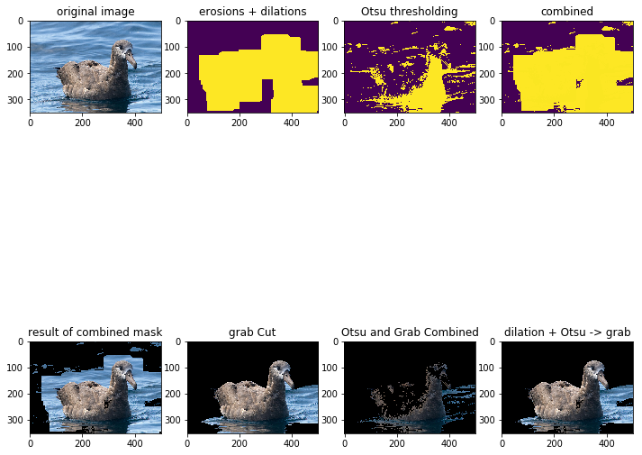

```python
sample('1.jpg')
```

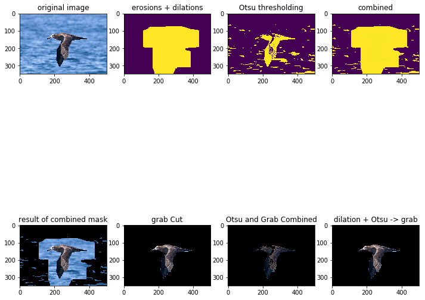

```python
sample('2.jpg')
```

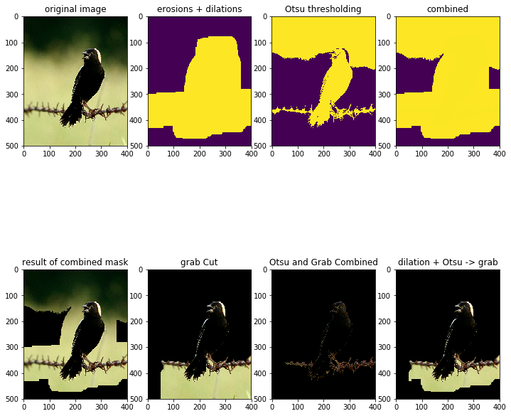

```python
sample('3.jpg')
```

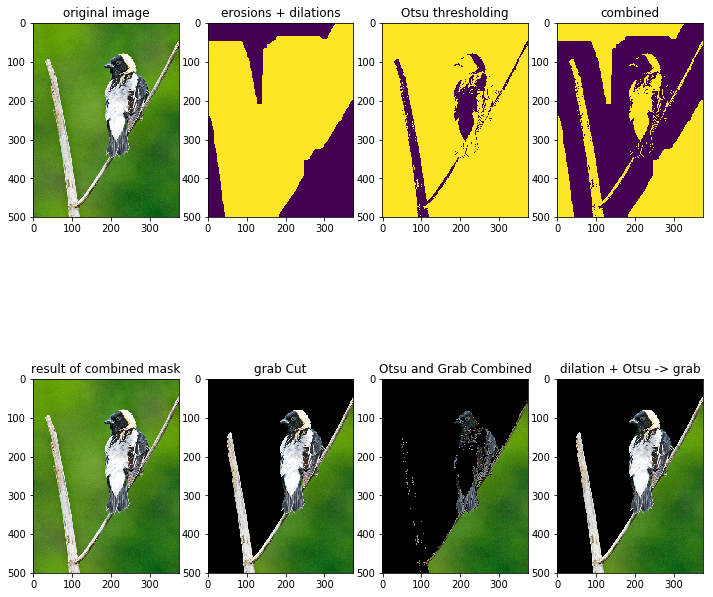

```python
sample('4.jpg')
```

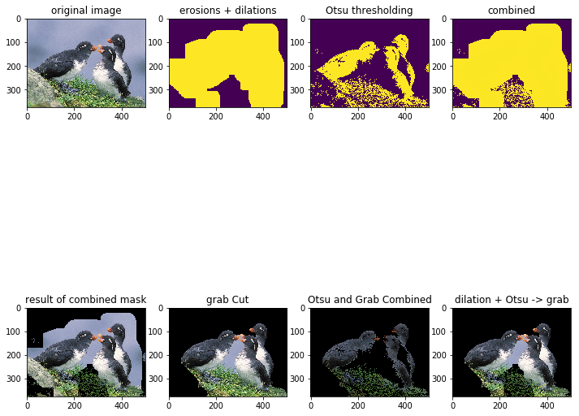

```python
sample('5.jpg')
```

# In this point, I decide to use the combined mask of dilation + erotion and the Otsu thresholding. Then it applied the mask of the grab Cut.

### Dilation + erotion can first get the "shape" of the image. Otsu threasholding has very pleasing result if human effort is involved (like it has a really good shape sometimes), but it omits a lot of important ares. The dilation and erotion method dependes on the threashold I input. I would rather input a larger value, since I would prefer to contain more "useless" area rather than losting "important area".

### The result of this dilation + erotion and Otsu mask is "huge", as it contains way more useless areas than it should. So the grab cut was like a better smaller and more accurate mask applied on the image. As we can see in the result, most of the job is done by the grab cut. But the former mask sometimes can remove areas that grab cut along cannot.

```python
def change_image(name):
    windowName = "Edges"
    pictureRaw = cv2.imread(name)

    #the erosion + dilation
    pictureGray = cv2.cvtColor(pictureRaw,  cv2.COLOR_BGR2GRAY)
    pictureGaussian = cv2.GaussianBlur(pictureGray, (21,21), 0)
    pictureCanny = cv2.Canny(pictureGaussian, 50, 100)
    pictureDilate = cv2.dilate(pictureCanny, None, iterations= 50)
    pictureErode = cv2.erode(pictureDilate, None, iterations=5)

    #Otsu thresholding
    Otsu = pictureRaw
    Otsugray = cv2.cvtColor(Otsu,cv2.COLOR_BGR2GRAY)
    Otsuret, Otsuthresh = cv2.threshold(Otsugray,0,255,cv2.THRESH_BINARY_INV+cv2.THRESH_OTSU)


    #combined
    combined = Otsuthresh + pictureErode

    #masked result
    imask = combined > 0
    canvas = np.full_like(pictureRaw, np.array([0,0,0]), dtype=np.uint8)
    canvas[imask] = pictureRaw[imask]


    #grab cut
    grabimg = pictureRaw
    grabmask = np.zeros(grabimg.shape[:2],np.uint8)
    grabbgdModel = np.zeros((1,65),np.float64)
    grabfgdModel = np.zeros((1,65),np.float64)
    grabrect = (50,50,1000,1000)
    try:
        cv2.grabCut(grabimg,grabmask,grabrect,grabbgdModel,grabfgdModel,5,cv2.GC_INIT_WITH_RECT)
    except:
        print(name)
    grabmask2 = np.where((grabmask==2)|(grabmask==0),0,1).astype('uint8')
    grabimg = grabimg*grabmask2[:,:,np.newaxis]

    #combined of all things
    #first filter the image by applying erosions + dilations and Otsu
    #then filter the resulting image by applying grab Cut
    combinedImage = (canvas*grabmask2[:,:,np.newaxis])[:,:,::-1]
    imageio.imsave(name, combinedImage)
```

```python
def remove_all_backgrounds():
    for folder_name in glob.glob('images/*'):
        print('***' + folder_name + '***')
        name_list = []
        for name in glob.glob('%s/*' %folder_name):
            if (name.endswith(".jpg")):
                name_list.append(name)
        for name in name_list:
            change_image(name)
```

```python
def remove_black():
    for folder_name in glob.glob('images/*'):
        name_list = []
        for name in glob.glob('%s/*' %folder_name):
            if (name.endswith(".jpg")):
                name_list.append(name)
        for name in name_list:
            if ((sum(sum(sum(np.int32(cv2.imread(name)))))) < 10000):
                os.remove(name)
```

```python
def grey_image():
    for folder_name in glob.glob('images/*'):
        print('***' + folder_name + '***')
        name_list = []
        for name in glob.glob('%s/*' %folder_name):
            if (name.endswith(".jpg")):
                name_list.append(name)
        for name in name_list:
            im = Image.open(name).convert('LA')
            rgb_im = im.convert('RGB')
            rgb_im.save(name)
```

```python
def smaller_sample(inputnumber):
    for folder_name in glob.glob('images/*'):
        name_list = []
        for name in glob.glob('%s/*' %folder_name):
            if (name.endswith(".jpg")):
                name_list.append(name)
        for name in name_list:
            number = int((name[(len(folder_name)+1):-4]))
            if number > inputnumber:
                os.remove(name)
```

```python
def change_all_images_final():
    change_all_size()
    smaller_sample(20)
    remove_all_backgrounds()
    remove_black()
#change_all_images_final()
```

```python
def final_model_1():
    all_X = put_in_numpy_array()
    all_X = np.array(all_X)
    All_Flat_X = np.array([image.flatten() for image in all_X])
    all_Y = get_all_Y()
    sanity_check(all_X, all_Y)
    (Train_X, Test_X, Train_y, Test_y) = split_train_and_test(All_Flat_X, all_Y)
    model = fit_model(Train_X, Train_y, Test_X, Test_y)
    return model
```

```python
def final_model_2():
    all_X = put_in_numpy_array2()
    all_X = np.array(all_X)
    All_Flat_X = np.array([image.flatten() for image in all_X])
    all_Y = get_all_Y2()
    sanity_check(all_X, all_Y)
    (Train_X, Test_X, Train_y, Test_y) = split_train_and_test(All_Flat_X, all_Y)
    model = fit_model(Train_X, Train_y, Test_X, Test_y)
    return model
```

```python
model1 = final_model_1()
model2 = final_model_2()
```

```
(3630, 192, 192, 3)
(3630,)
(3630, 110592)
2904 2904 726 726
[ 0  0  0 ... 77 83 49]
```

```
0.016920016252088856
0.013555507853028514
[[0 1 0 ... 0 0 0]
 [0 0 0 ... 0 0 0]
 [0 0 0 ... 0 0 0]
 ...
 [0 0 0 ... 0 0 0]
 [0 0 0 ... 0 0 0]
 [0 0 0 ... 1 0 0]]
(4000, 192, 192, 3)
(4000,)
(4000, 110592)
3200 3200 800 800
[ 64 103  59 ...  96  83  66]
```

```
0.02541056777791964
0.027159661732746098
[[0 0 0 ... 0 0 0]
 [0 0 0 ... 0 0 0]
 [0 0 0 ... 0 0 0]
 ...
 [0 0 0 ... 0 0 0]
 [0 0 0 ... 0 0 0]
 [0 0 0 ... 0 0 0]]
```

```python
def random_test(name):
    new_image = (cv2.imread('images/' + name))
    test = [((np.array(new_image)).flatten())]
    test = np.array(test)
    print('result of 1')
    try:
        print(model1.predict(test))
    except:
        print('not this image')
    new_image = (cv2.imread('images2/' + name))
    test = [((np.array(new_image)).flatten())]
    test = np.array(test)
    print('result of 2')
    print(model2.predict(test))
```

```python
def some_test():
    for i in range(21):
        if (i != 0):
            print(i)
            random_test('001.Black_footed_Albatross/%s.jpg' %i)
```

```python
store_model(model1, 'model1')
store_model(model2, 'model2')
```

```python
test_1 = open_model('model1')
test_2 = open_model('model2')
```

```python
#sample result to test that this actually store the model
test_1.predict(np.array([((np.array((cv2.imread('images/001.Black_footed_Albatross/2.jpg')))).flatten())]))
```

```
array(['145'], dtype='<U3')
```

```python
test_2.predict(np.array([((np.array((cv2.imread('images/001.Black_footed_Albatross/2.jpg')))).flatten())]))
```

```
array(['045'], dtype='<U3')
```